# Accounting for Spatial Autocorrelation

Michael L. Treglia

Material for Lab 7 of Landscape Analysis and Modeling, Spring 2015

**Due Date: Thursday, 12 March 2015**

*PLEASE WRITE YOUR NAME ON YOUR ANSWER DOCUMENT*

# Questions

1. What is the default number of permutations used for calculating the mantel test statistic?
2. Based on a Mantel test, is there a significant relationship between temperature and boreality? Provide Mantel’s r and the p-value.
3. Based on a partial Mantel test, is there a significant relationship between temperature and boreality when controlling for spatial effects? (Provide Mantel’s r value and the p-values).
4. Plot a Moran’s *I* correlogram for the residuals of boreality as a function of wetness from a linear model that does not account for spatial autocorrelation.

# Introduction

Though it is informative to identify whether there is spatial autocorrelation for individual variables (e.g., with Moran’s *I* or Geary’s *c*), as we did in Lab 6, in ecology and evolutionary biology, we are often interested in the relationships of multiple variables. For example, how does temperature affect tree size or the ecological community of species at a site? As we discussed in lecture, the effect of spatial autocorrelation can obscure actual patterns in the data, thus we must deal with this appropriately.

We will focus this lab on an example from Chapter 7 of the book *Mixed Effects Models and Extensions in Ecology with R* by Alain Zuur et al, as part of [Highland Statistics](http://www.highstat.com). You can check out the book’s website, here: http://www.highstat.com/book2.htm. This group has a few books on analyzing ecological data with R - I recommend looking into their books for topics you may use in your research, and definitely check out their published papers too.

You can download [R code](http://www.highstat.com/Book2/ZuurMixedModellingAllRCode.zip) and [data](http://www.highstat.com/Book2/ZuurDataMixedModelling.zip) used in the book at the book’s website. We will focus on the “Boreality” dataset (Boreality.txt).

The focal dataset is centered on characterization of forest communities in part of British Colombia, Canada. The dependent variable is a metric of how many species present are associated with boreal forests; other variables include x- and y-coordinates, the data used to compute the boreality index, and remotely sensed measures of temperature (‘T61’), Greenness (‘GRN’) and Wetness (‘Wet’). Herein, we will only focus on a transformed metric of the Boreality index, wetness, and location (x- and y-coordinates). Here, we will look at the relationships between wetness and boreality, but you will also look at the remotely sensed temperature for the assignment. You will examine the data using Mantel tests, linear regression, and generalized least squares (GLS) regression techniques.

## Necessary R Packages

The packages we will use in this lab are:

- [ecodist](http://cran.r-project.org/web/packages/ecodist/index.html)
- [gstat](http://cran.r-project.org/web/packages/gstat/index.html)
- [nlme](http://cran.r-project.org/web/packages/nlme/index.html)
- [sp](http://cran.r-project.org/web/packages/sp/index.html)

(See previous lab materials for instructions on installing and loading packages in R.)

# Importing and Setting Up the Data

As per usual, it often helpful to set your working directory appropriately and load any required packages. Then, you can import the dataset (you will have to have the data downloaded and un-zipped from the website linked above.) To open these data, you will use the ‘read.table’ function in R. Previously we have used the ‘read.csv’ function, which is a special case of read.table, for comma-separated values files. The Boreality dataset is stored in a tab-delimited format. While there are lots of arguments available for read.table, the only additional one you’ll need to use after the filename is ‘header=TRUE’, indicating that the first row of information is the column names. We’ll name the imported data ‘Boreality’.

```r
Boreality <- read.table("Boreality.txt", header=TRUE)
```

To calculate Boreality for analysis, it run the following line, creating a new variable ‘Bor’

```r
Boreality$Bor<-sqrt(1000*(Boreality$nBor+1)/(Boreality$nTot))
```

# Running Mantel Test

Though we have discussed the problems with Mantel tests in lecture, and they are well documented in the literature (e.g., [Guillot and Rousset 2014](http://onlinelibrary.wiley.com/doi/10.1111/2041-210x.12018/abstract)), you may wish to explore the analyses with data.

As discussed in class, Mantel tests are based on distance or similarity matrices, characterizing physical distance between sample units, and similarity or dissimilarity between values for variables at different sample units. Thus, we will calculate these using the ‘[ecodist](http://cran.r-project.org/web/packages/ecodist/index.html)’ package, designed for calculating and working with distance/similarity metrics.

For characterizing differences based on multiple variables at once (representing a multivariate dissimilarity), you would likely want to use Mahalanobis distance - see this useful page on StackExchange: http://stats.stackexchange.com/questions/62092/bottom-to-top-explanation-of-the-mahalanobis-distance.

We will calculate these using the ‘dist’ function in base R (i.e., it is a default function of R), setting the method argument as ‘euclidean’. You can also do this via the ‘distance’ function in the ‘ecodist’ package that we will use for the mantel test (which also allows calculation of Mahalanobis distance), but it is a bit slower in that package. For analysis of ecological communities, a wide variety of similarity metrics are also available in the ‘vegdist’ function of the ‘vegan’ package.

```r
geog.dist <- dist(Boreality[, c("x", "y")], method = "euclidean")
bor.dist <- dist(Boreality$Bor, method = "euclidean")
wet.dist <- dist(Boreality$Wet, method = "euclidean")
```

The function for calculating both regular and partial Mantel tests is ‘mantel’. In the regular Mantel test, the main argument needed is the model being tested - basically, is one distance matrix related to another matrix (written as ‘matrix1 ~ matrix2’). We can do this for all possible combinations here for exploratory purposes. Shown below is the code for testing relationships between geographic distance, similarity in boreal index, and similarity in wetness. As with other functions, it is worth checking out the possible arguments for ‘mantel’.

```r
mantel(bor.dist~geog.dist)
mantel(wet.dist~geog.dist)
mantel(bor.dist~wet.dist)
```

[output not shown]

```
  mantelr      pval1      pval2      pval3  llim.2.5% ulim.97.5%
0.08336013 0.00100000 1.00000000 0.00100000 0.06979311 0.09794219
```

To carry out a partial Mantel test in the ecodist package, we simply add an extra term onto the formula - the matrix which we want to correct for. In this case, we might want to see if there’s a significant effect of wetness on boreality, while controling for variation in space, so the code would be:

```r
mantel(bor.dist~wet.dist+geog.dist)
```

[output not shown]

The results are interpreted the same as above, but it should be understood that the effect of geographic distance is removed. Remember, Mantel tests have their problems, so you should check results with other techniques.

# Spatial Regression

*Note: R code below is adapted from the aforementioned book by Zuur et al.*

In linear regression, one of the major assumptions is that measurements are ‘independent and identically distributed’ (‘i.i.d.’) - in other words, that all values within the population have the same probability of being sampled. Spatial autocorrelation violates this assumption, as samples close to one another have a higher probability of being similar in value. We can see this effect by conducting a simple linear regression with the data and looking at the residuals. If there is no spatial autocorrelation, the residuals (i.e., error from the model) will be randomly distributed in space, but if there is autocorrelation, the residuals will show spatial patterns. Here, we will focus on boreality as a function of wetness.

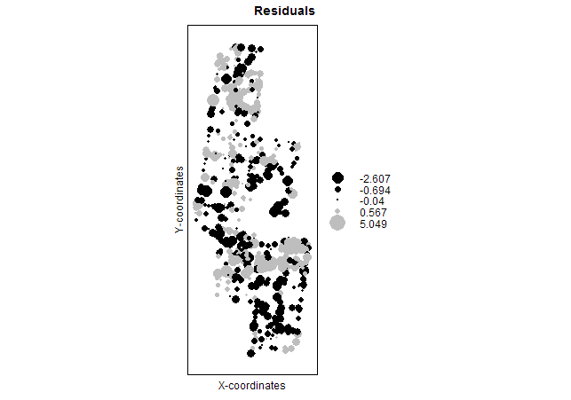

```r
#Calculate the linear model
B.lm<-lm(Bor~Wet,data=Boreality)

#You can calculate the f-statistic and p-value for this using
anova(B.lm)
#Not necessarily desired; see:
# https://stat.ethz.ch/pipermail/r-help/2006-May/094765.html

#Extract standardized residuals (rstandard(LinearModel))
lm.resids <- rstandard(B.lm)

#Create SpatialPointsDataFrame of residuals and x/y coords
lm.resids.spdf<-data.frame(lm.resids,Boreality$x,Boreality$y)
coordinates(lm.resids.spdf)<-c("Boreality.x","Boreality.y")

#Create bubble plot (sp package)
bubble(resids.spdf,"resids",col=c("black","grey"),
       main="Residuals",xlab="X-coordinates",
       ylab="Y-coordinates")
```

As you can see, there appears to be clustering of high and low residual values.

We can visualize and spatial autocorrelation in the residuals as we did last week using the ‘pgirmess’ package and the function ‘correlog’ (Look back to Lab 6)

We can also calculate and plot a variogram of the residuals, using the ‘variogram’ function in the ‘gstat’ package.

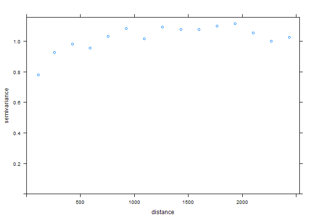

```r
lm.residVario <- variogram(lm.resids ~ 1, lm.resids.spdf)
plot(lm.residVario)
```

You can see there seems to be an increasing semivariance with increasing distance up to ~500-1000 units.

Though the above variogram assumes isotropy, you can explore the variogram in different directions using this code:

```r
plot(variogram(lm.resids ~ 1, lm.resids.spdf, alpha = c(0, 45, 90,135) ))
plot(Vario2)
```

[output not shown]

So, how can we correct for this?